# Introduction to Likelihood Estimation

K. Enevoldsen

2/13/2021

This is a annotated implementation of the paper *“Introduction to the Concept of Likelihood and Its Applications”* by (Etz 2018). It does not go though the entire paper but it does consider the most essential points. It is inspired the the Annotated Transformer by (Rush 2018). This article will mainly contains snippets from the original as well as annotation which will be marked using a highlight. It will also contain an extended application at the end.

## Abstract

This Tutorial explains the statistical concept known as likelihood and discusses how it underlies common frequentist and Bayesian statistical methods. The article is suitable for researchers interested in understanding the basis of their statistical tools and is also intended as a resource for teachers to use in their classrooms to introduce the topic to students at a conceptual level.

## Introductions

Likelihood is a concept that underlies most common statistical methods used in psychology. It is the basis of classical methods of maximum likelihood estimation, and it plays a key role in Bayesian inference. However, despite the ubiquity of likelihood in modern statistical methods, few basic introductions to this concept are available to the practicing psychological researcher. The goal of this Tutorial is to explain the concept of likelihood and illustrate in an accessible way how it enables some of the most used kinds of classical and Bayesian statistical analyses; given this goal, I skip over many finer details, but interested readers can consult Pawitan (2001) for a complete mathematical treatment of the topic (see Edwards, 1974, for a historical review). This Tutorial is aimed at applied researchers interested in understanding the basis of their statistical tools and can also serve as a resource for introducing the topic of likelihood to students at a conceptual level. Likelihood is a strange concept in that it is not a probability but is proportional to a probability. The likelihood of a hypothesis ($H$) given some data ($D$) is the probability of obtaining $D$ given that $H$ is true multiplied by an arbitrary positive constant $K$: $L(H) = K × P(D|H)$.

In most cases, a hypothesis represents a value of a parameter in a statistical model, such as the mean of a normal distribution. Because a likelihood is not actually a probability, it does not obey various rules of probability; for example, likelihoods need not sum to 1.

A critical difference between probability and likelihood is in the interpretation of what is fixed and what can vary. In the case of a conditional probability, $P(D|H)$, the hypothesis is fixed and the data are free to vary. Likelihood, however, is the opposite. The likelihood of a hypothesis, $L(H)$, is conditioned on the data, as if they are fixed while the hypothesis can vary. The distinction is subtle, so it is worth repeating: For conditional probability, the hypothesis is treated as a given, and the data are free to vary. For likelihood, the data are treated as a given, and the hypothesis varies.

## The likelihood Axiom

Edwards (1992) synthesized two statistical concepts — the law of likelihood and the likelihood principle — to define a likelihood axiom that can form the basis for interpreting statistical evidence. The law of likelihood states that *“within the framework of a statistical model, a particular set of data supports one statistical hypothesis better than another if the likelihood of the first hypothesis, [given] the data, exceeds the likelihood of the second hypothesis”* (Edwards, 1992, p. 30). In other words, there is evidence for $H_1$ over $H_2$ if and only if the probability of the data under $H_1$ is greater than the probability of the data under $H_2$. That is, D is evidence for $H_1$ over $H_2$ if $P(D|H_1) > P(D|H_2)$. If these two probabilities are equivalent, then there is no evidence for either hypothesis over the other. Furthermore, the strength of the statistical evidence for $H_1$ over $H_2$ is quantified by the ratio of their likelihoods, which is written as $LR(H_1, H_2) = L(H_1)/L(H_2)$ — which is equal to $P(D|H_1)/P(D|H_2)$ because the arbitrary constants cancel out of the fraction.

The following brief example illustrates the main idea underlying the law of likelihood. Consider the case of Earl, who is visiting a foreign country that has a mix of women-only and mixed-gender saunas (the latter known to be visited equally often by men and women). After a leisurely jog through the city, he decides to stop by a nearby sauna to try to relax. Unfortunately, Earl does not know the local language, so he cannot deter- mine from the posted signs whether this sauna is for women only or both genders. While Earl is attempting to decipher the signs, he observes three women inde- pendently exit the sauna. If the sauna is for women only, the probability that all three exiting patrons would be women is 1.0; if the sauna is for both genders, this probability is .125 (i.e., .53). With this information, Earl can compute the likelihood ratio between the women - only hypothesis and the mixed-gender hypothesis to be 8 (i.e., 1.0/.125); in other words, the evidence is 8 to 1 in favor of the sauna being for women only. The likelihood principle states that the likelihood function contains all of the information relevant to the evaluation of statistical evidence. Other facets of the data that do not factor into the likelihood function (e.g., the cost of collecting each observation or the stopping rule used when collecting the data) are irrelevant to the evaluation of the strength of the statistical evidence (Edwards, 1992, p. 30; Royall, 1997, p. 22). They can be meaningful for planning studies or for decision analysis, but they are separate from the strength of the statistical evidence. Edwards (1992) defined the likelihood axiom as a natural combination of the law of likelihood and the likelihood principle. The likelihood axiom takes the implications of the law of likelihood together with the likelihood principle and states that the likelihood ratio comparing two statistical hypotheses contains *“all the information which the data provide concerning the relative merits”* of those hypotheses (p. 30).

## Likelihoods Are Meant to Be Compared

Unlike a probability, a likelihood has no real meaning per se, because of the arbitrary constant K. Only through comparison do likelihoods become interpretable, because the constants cancel one another out. An example using the binomial distribution provides a simple way to explain this aspect of likelihood. Suppose a coin is flipped $n$ times, and we observe $x$ heads and $n – x$ tails. The probability of getting $x$ heads in n flips is defined by the binomial distribution as follows:

$$P(X=x|p) =\binom nk \cdot p \cdot (1−p)
\tag{1}$$
where p is the probability of heads and the binomial coefficient,

$$\binom nk = \frac{n!}{x!(n-x)!}$$
counts the number of ways to get x heads in n flips.

For the reader unfamiliar the binomial distribution, I suggest watching this wonderful video right here before moving on:

[video not shown]

For example, if $x = 2$ and $n = 3$, the binomial coefficient is calculated as $3!/(2! × 1!)$, which is equal to 3; there are three distinct ways to get two heads in three flips (i.e., head-head-tail, head-tail-head, tail-head-head). Thus, the probability of getting two heads in three flips if p is $.50$ would be $.375( 3 ×.50^2 × (1–.50)^1)$, or 3 out of 8. If the coin is fair, so that $p = .50$, and we flip it 10 times, the probability of six heads and four tails is

$$P(X =6|p=.50)= \frac{10!}{6! × 4!} (.50)^6(1−.50)^4 ≈.21$$
If the coin is a trick coin, so that $p = .75$, the probability of six heads in 10 tosses is

$$P(X =6|p=.75)= \frac{10!}{6! × 4!} (.75)^6(1−.75)^4 ≈.15.$$

To quantify the statistical evidence for the first hypothesis against the second, we simply divide one probability by the other. This ratio tells us everything we need to know about the support the data lend to the fair-coin hypothesis vis-à-vis the trick-coin hypothesis. In the case of six heads in 10 tosses, the likelihood ratio for a fair coin versus the trick coin, denoted $LR(.50,.75)$, is
$$LR(.50,.75) = \left( \frac{10!}{6! × 4!} (.50)^6 (1 − .50)^4 \right) ÷ \left( \frac{10!}{6! × 4!} (.75)^6 (1 − .75)^4 \right) ≈ .21/.15 = 1.4$$
In other words, the data are $1.4$ times more probable under the fair-coin hypothesis than under the trick-coin hypothesis. Notice how the first terms in the two equations, $10!/(6! × 4!)$, are equivalent and completely cancel each other out in the likelihood ratio.

The first term in these equations reflects the rule we used for ending data collection. If we changed our sampling plan, the term’s value would change, but crucially, because it is the same term in the numerator and denominator of the likelihood ratio, it always cancels itself out. For example, if we were to change our sampling scheme from flipping the coin 10 times and counting the number of heads to flipping the coin until we get six heads and counting the number of flips, this first term would change to $9!/(5! × 4!)$ because the final trial would be predetermined to be a head (Lindley, 1993). But, crucially, because this term is in both the numerator and the denominator, the information contained in the way the data were obtained would disappear from the likelihood ratio. Thus, because the sampling plan does not affect the likelihood ratio, the likelihood axiom tells us that the sampling plan can be considered irrelevant to the evaluation of statistical evidence, which makes likelihood and Bayesian methods particularly flexible (Gronau & Wagenmakers, in press; Rouder, 2014). Consider if we leave out the first term in our calculations after observing six heads in 10 coin tosses, so that our numerator is $P(X = 6|p = .50) = (.50)^6(1 – .50)^4 = 0.000976$ and our denominator is $P(X = 6|p = .75) = (.75)^6(1 – .75)^4 = 0.000695$. Using these values to form the likelihood ratio, we get $LR(.50,.75) = 0.000976/ 0.000695 = 1.4$, confirming our initial result because the other terms simply canceled out before. Again, it is worth repeating that the value of a single likelihood is meaningless in isolation; only in comparing likelihoods do we find meaning.

## Inference using the likelihood function

### Visual inspection

So far, likelihoods may seem overly restrictive because we have compared only two simple statistical hypotheses in a single likelihood ratio. But what if we are interested in comparing all possible hypotheses at once? By plotting the entire likelihood function, we can *“see”* the full evidence the data provide for all possible hypotheses simultaneously. Birnbaum (1962) remarked that *“the ‘evidential meaning’ of experimental results is characterized fully by the likelihood function”* (p. 269), so let us look at some examples of likelihood functions and see what insights we can glean from them.

In the original paper the figure is supplied but for illustrative purposes let us take a moment to consider how to plot this ourselves. This will be done in R. Furthermore coin-flip examples can be quite arbitrary so let’s (like in the video) consider number of positive and negative reviews and try to estimate the true probability of a positive review. This should naturally reflect the underlying quality of the product you want to buy

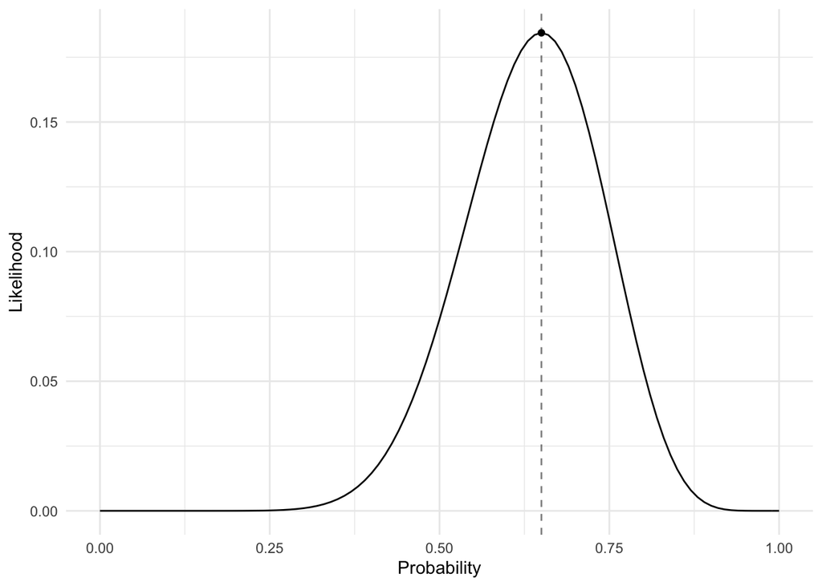

Fig. 1: A plot showing the likelihood over p. Note that a few extra thing have been added to the plot beyond the code.

```r
library(tidyverse)

# our observed data
n_positive = 13
n_negative = 7
number_of_reviews = n_negative + n_positive

p = seq(0, 1, by = 0.01)  # create a grid for the x-axis in step of 0.01 (this is our proposed values of p)
likelihood = dbinom(n_positive, size=number_of_reviews, prob=p)

data = tibble(p, likelihood)
plot = ggplot(data, aes(p, likelihood)) +
  geom_line()
plot # display plot
```

The reader is now encourages to - 1) explain the `dbinom` function - 2) change the number of positive and negative to see how it changes the results - 2.1) What happens if you multiply the number of negative and positives by 2? - 2.2) What happens if you only see 2 positive review?

We need to be careful not to make blanket statements about absolute support, such as claiming that the hypothesis with the greatest likelihood is *“strongly supported by the data.”* Always ask what the comparison is with. The best-supported hypothesis will usually be only weakly supported against any hypothesis positing a value that is a little smaller or a little larger .3 For example, in the case of 60 positive reviews out of total reviews, the likelihood ratio comparing the hypotheses that $p = .60$ and $p = .75$ is very large, $LR(.60,.75) = 224$, whereas the likelihood ratio comparing the hypotheses that $p = .60$ and $p = .65$ is much smaller, $LR(.60,.65) = 1.7$, and provides barely any support one way or the other. Consider the following common real-world research scenario: We have run a study with a relatively small sample size, and the estimate of the effect of primary scientific interest is considered *“large”* by some criteria (e.g., Cohen’s $d > 0.75$). We may find that the estimated effect size from the sample has a relatively large likelihood ratio compared with a hypothetical null value (i.e., a ratio large enough to “reject the null hypothesis”; see the next section), but that the likelihood ratio is much smaller when the comparison is with a *“medium”* or even *“small”* effect size. Without relatively large sample sizes, one is often precluded from saying anything precise about the size of the effect because the likelihood function is not very peaked when samples are small.

## Maximum likelihood estimation

A natural question for a researcher to ask is, what is the hypothesis that is most supported by the data? This question is answered by using a method called maxi- mum likelihood estimation (Fisher, 1922; see also Ly, Marsman, Verhagen, Grasman, & Wagenmakers, 2017, and Myung, 2003). In the plots in Figure 1, the vertical dotted lines mark the value of $p$ that has the highest likelihood; this value is known as the *maximum likelihood estimate*. We interpret this value of $p$ as being the value that makes the observed data the most probable. Because the likelihood is proportional to the probability of the data given the hypothesis, the hypothesis that maximizes $P(D|H)$ will also maximize $L(H)$. In the case of simple problems, plotting the likelihood function will reveal an obvious maximum. For example, the maximum of the binomial likelihood function will be located at the proportion of successes observed in the sample. Box 1 (located in the appendix) shows this to be true using a little bit of elementary calculus.

With the maximum likelihood estimate in hand, there are a few possible ways to proceed with classical inference. First, one can perform a likelihood ratio test comparing two versions of the proposed statistical model: one in which the parameter of interest, $\theta$, is set to a hypothesized null value and one in which the parameter is estimated from the data (the null model is said to be nested within the second model because it is a special case of the second model in which the parameter equals the null value). In practice, this amounts to comparing the value of the likelihood at the maximum likelihood estimate, $\theta_{mle}$, and the value of the likelihood at the proposed null value, $\theta_{null}$. Likelihood ratio tests are commonly used to draw inferences with structural equation models. In the case of the binomial coin-toss example from earlier in this Tutorial, we would compare the probability of the data if p were .50 (the fair-coin hypothesis) with the probability of the data given the value of p estimated from the data (the maximum likelihood estimate). In general, it can be shown that when the null hypothesis is true, and as the sample size gets large, twice the logarithm of this likelihood ratio approximately follows a chi-squared distribution with a single degree of freedom (Casella & Berger, 2002, p. 489; Wilks, 1938):

$$2log \left( \frac{P(X|\theta_{mle})}{P(X|\theta_{null})} \right) \dot\sim \chi^2(1)
\tag{2}$$

where $\dot\sim$ means *“is approximately distributed as.”* If the value of the quantity on the left-hand side of Equation 2 is large enough (i.e., lies far enough out in the right tail of the chi-squared distribution), such that the p value is lower than a prespecified cutoff α (often chosen to be .05), then one would make the decision to reject the hypothesized null value.

Let is just pause the article here and see how this would be implemented in code. First we will need to calculate the maximum likelihood estimate $P(X|\theta_{mle})$ and the likelihood of the null $P(X|\theta_{null})$:

```r
h0 <- likelihood[p==0.5]
ha <- likelihood[p==maximum_likelihood]

h0
```

```
## [1] 0.07392883
```

```r
ha
```

```
## [1] 0.1844012
```

Then we can simply calculate the likelihood ratio and calculate the p-value using the chi-squared $\chi^2$:

```r
lik_ratio <- 2*log(ha/h0)

p_value = pchisq(q = lik_ratio, df = 1, lower.tail = F)
p_value
```

```
## [1] 0.1763614
```

We see here that in fact the we cannot reject (given a significance threshold of 0.05) that the reviews we see were indeed given by chance.

The reader is now encouraged to - 3) assuming we have 7 negative review, test how many positive reviews would be needed to get a p-value < 0.05 - 4) how many would be need in the significance threshold was 0.001 instead?

Here the papers original goes into an another alternative, called Wald’s test, but it only touches on it briefly and without enough information to truly understand it nor implement it. Thus it is left out. The interested reader is naturally referred to the paper itself. Instead we will look at the more relevant alternative:

## Bayesian updating via. the likelihood

As we have seen, likelihoods form the basis for much of classical statistics via the method of maximum likelihood. estimation. Likelihoods are also a key component of Bayesian inference. The Bayesian approach to statistics is fundamentally about making use of all available information when drawing inferences in the face of uncertainty. This information may be the results from previous studies, newly collected data, or, as is usually the case, both. Bayesian inference allows one to synthesize these two forms of information to make the best possible inference. Previous information is quantified using what is known as a prior distribution. The prior distribution of θ, the parameter of interest, is $P(\theta)$; this is a function that specifies which values of θ are more or less likely, given one’s interpretation of previous relevant information. The information gained from new data is represented by the likelihood function, proportional to $P(D|θ)$, which is then multiplied by the prior distribution (and rescaled) to yield the posterior distribution, $P(θ|D)$, which is then used as the basis for the desired inference. Thus, the likelihood function is used to update the prior distribution to a posterior distribution. Interested readers can find a detailed technical introduction to Bayesian inference in Etz and Vandekerckhove (2017) and an annotated list of useful Bayesian-statistics references in Etz, Gronau, Dablander, Edelsbrunner, and Baribault (2017).

Mathematically, a well-known conditional-probability theorem , Bayes theorem, (first shown by Bayes, 1763) states that the procedure for obtaining the posterior distribution of $\theta$ is as follows:

$$P(θ|D) = K × P(θ) × P(D|θ)$$
In this context, $K$ is merely a rescaling constant and is equal to $1/P(D)$. We often write this theorem more simply as

$$P(θ | D) ∝ P(θ) × P(D | θ)$$
where $∝$ means *“is proportional to.”*

The reader might be more familiar with the formulation of bayes theorem as:

$$P(θ|D) = \frac{P(θ) × P(D|θ)}{P(D)}$$
but as noted by the author these formulations are equivalent.

The following example shows how to use the likelihood function to update a prior distribution into a posterior distribution. The simplest way to illustrate how likelihoods act as an updating factor is to use conjugate distribution families (Raiffa & Schlaifer, 1961). A prior distribution and likelihood function are said to be conjugate when multiplying them together and rescaling results in a posterior distribution in the same family as the prior distribution. For example, if one has binomial data, one can use a beta prior distribution to obtain a beta posterior distribution (see Box 2, , in the appendix ). Conjugate prior distributions are by no means required for doing Bayesian updating, but they reduce the mathematics involved and so are ideal for illustrative purposes.

Consider the previous example of observing 60 positive reviews out of 100. Imagine that going into a review site we suspect that the company might have added a few positive reviews to the pile or maybe that our friend have had a bad experience with the product. This assumption could be expressed in the following way:

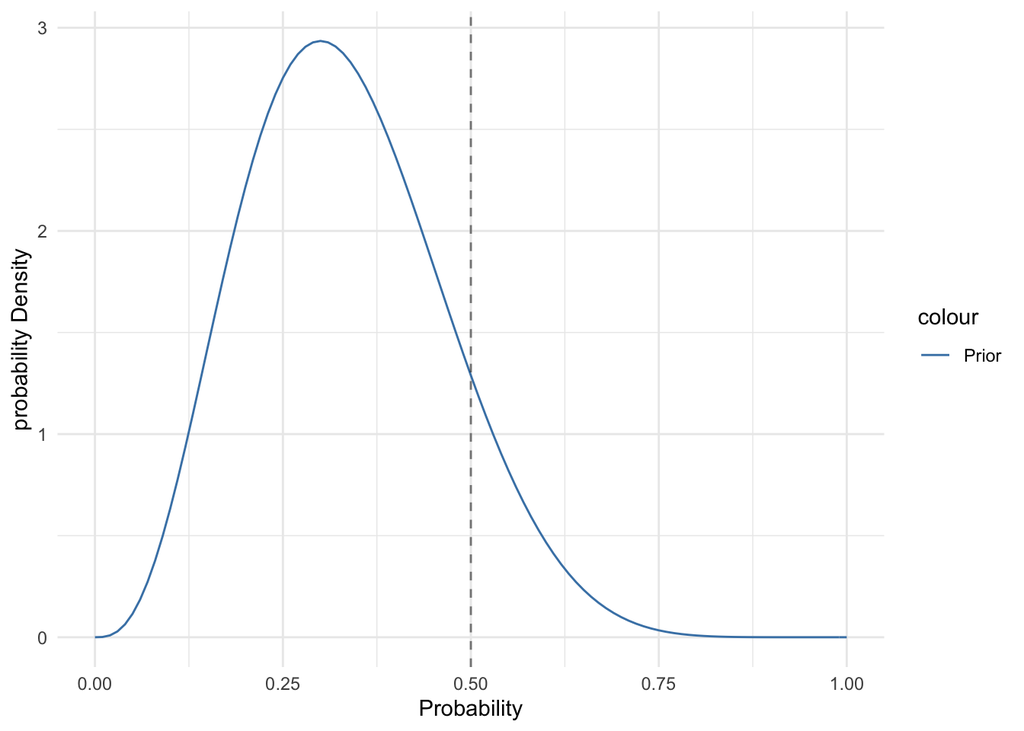

Fig. 2: A plot showing our prior belief over p. Note that a few extra thing have been added to the plot beyond the code.

```r
a = 4
b = 8
prior = dbeta(p, a, b)

data = tibble(p, prior)
plot = ggplot(data, aes(p, prior)) +
  geom_line(aes(color="Prior"))
plot
```

Note that this reflects our belief that reviews are slightly more likely to be negative, but still allows for the high chance of a positive review. To construct this prior we used a beta(a, b) distribution it is a distribution of probabilities as it spans from 0 to 1. The author of the original paper never touches upon what this really means (understandably so as it is slightly tricky to explain), but I believe it is relevant for understanding I thus recommend spending the time to watch this continuation of the previous video by 3Blue1Brown:

[video not shown]

The likelihood function for the 60 positive reviews out of 100 can now the added to the previous plot and we can multiply then together to get the posterior following Bayes theorem. Note that we rescale the posterior to sum to one as it is a probability. This corresponds to the constant $K$.

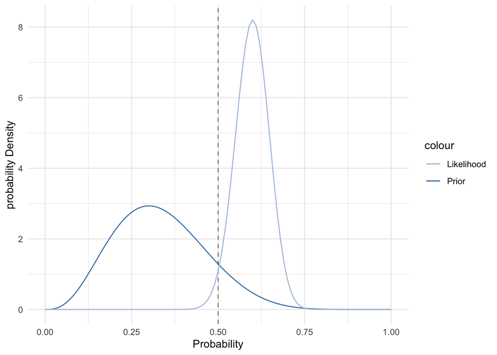

Fig. 2.1: A plot showing the prior and likelihood over p.

```r
# our observed data
n_positive = 60
n_negative = 40
number_of_reviews = n_negative + n_positive

likelihood = dbinom(n_positive, size=number_of_reviews, prob=p)

# rescale likelihood (simply so it looks nicer in the plot)
likelihood = likelihood/sum(likelihood)*100

# adding the likelihood to the plot
plot = plot +
  geom_line(aes(x=p, y=likelihood, color="Likelihood"))
plot
```

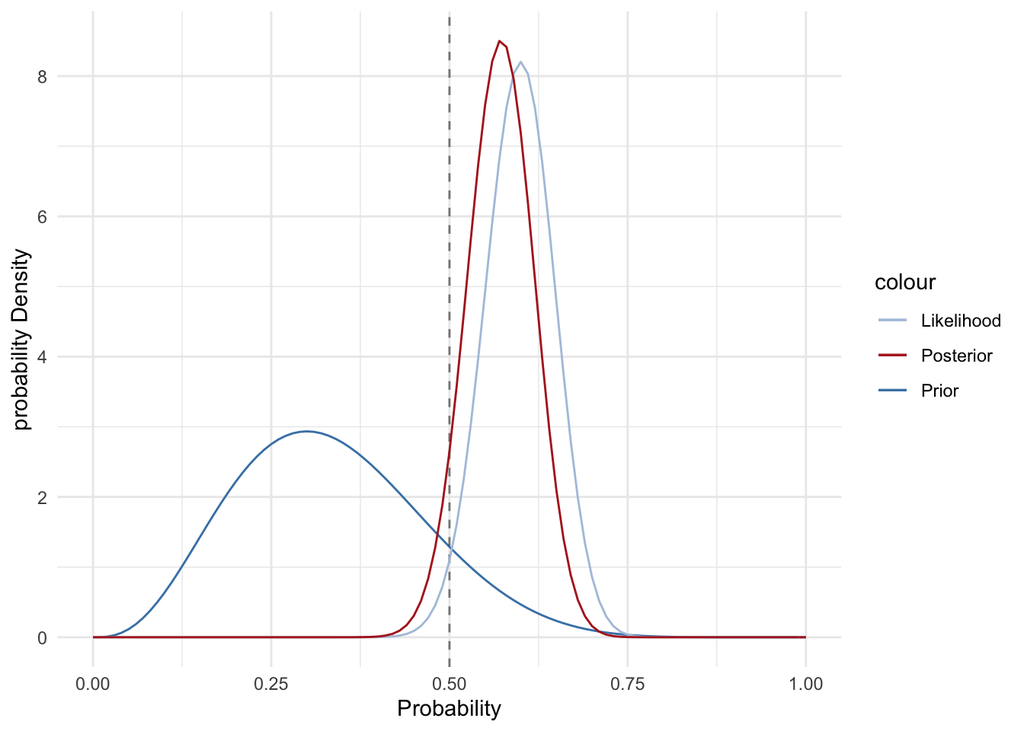

Fig. 2.2: A plot showing the prior, likelihood and posterior over p.

```r
posterior = likelihood*prior

# rescaling the posterior
posterior = posterior/sum(posterior)*100
# why 100? Well to make the integral equal to 1 because the interval between p is 0.01 (1/0.01=100). If you didn't do this it would look very small compared to the prior distribution when plotting (try it out)


# adding the posterior to the plot
plot +
  geom_line(aes(x=p, y=posterior, color="Posterior"))
```

From figure 2.2 it is then seen that the prior is updated, by the likelihood and results is the posterior. Thus we have now updated our previous belief given that seen data. Thus the Bayesian approach is especially relevant if you have information which you would like to incorperate. But let us return to the paper:

The entire posterior distribution represents the solution to our Bayesian estimation problem, but researchers often report summary measures to simplify the communication of results. For instance, we could point to the maximum of the posterior distribution—known as the maximum a posteriori estimate—as our best guess for the value of p, which in this case is 0.57.

Which can be calculated in R as follows:

```r
p[posterior == max(posterior)]
```

```
## [1] 0.57
```

```r
# this corresponds the argmax function, i.e. what is the value x which gives the largest value y?
```

## Conclusion

This Tutorial has defined likelihood, shown what a likelihood function looks like, and explained how this function forms the basis of two common inferential procedures: maximum likelihood estimation and Bayesian inference. The examples used were intentionally simple and artificial to keep the mathematical burden light, but I hope that they can give some insight into the fundamental statistical concept known as likelihood.

Furthermore, additional code examples to further illustrated how one might go about practically implementing this. Furthermore these should allow researcher and student to experiment with the results to further their own learning. Lastly, it provides a crucial step in translating between formulas and code. A step which is too often left as an exercise to the reader.

# Appendix

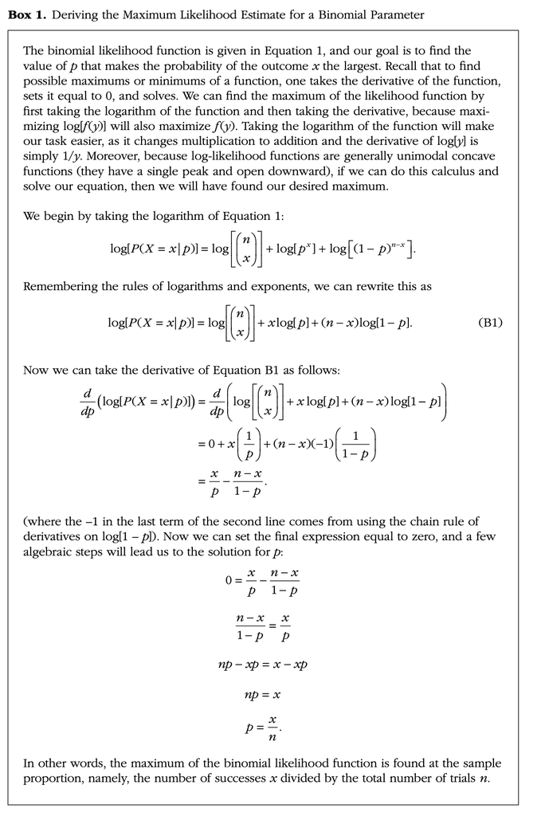

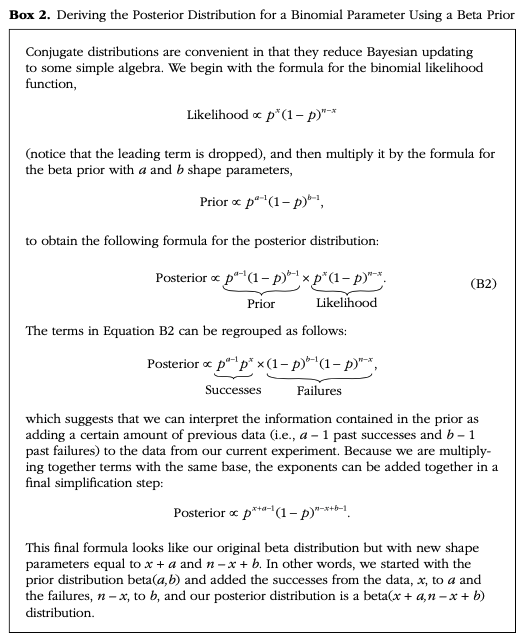

# References

## Original references:

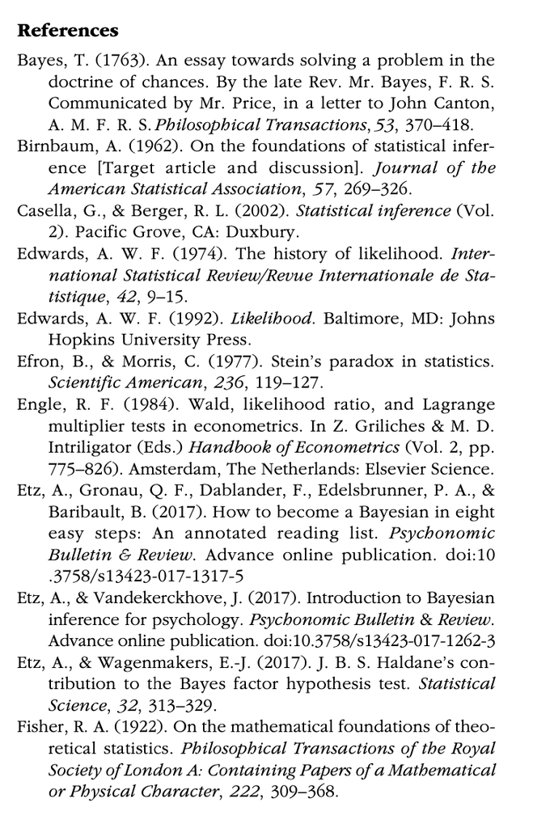

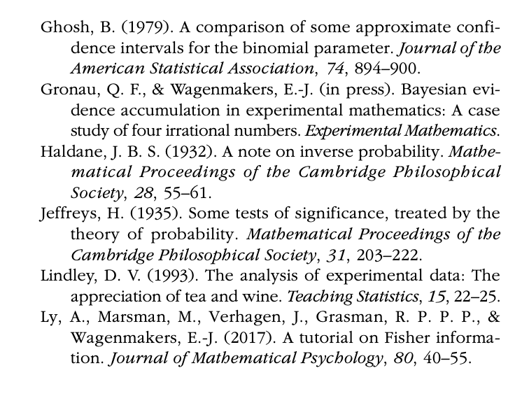

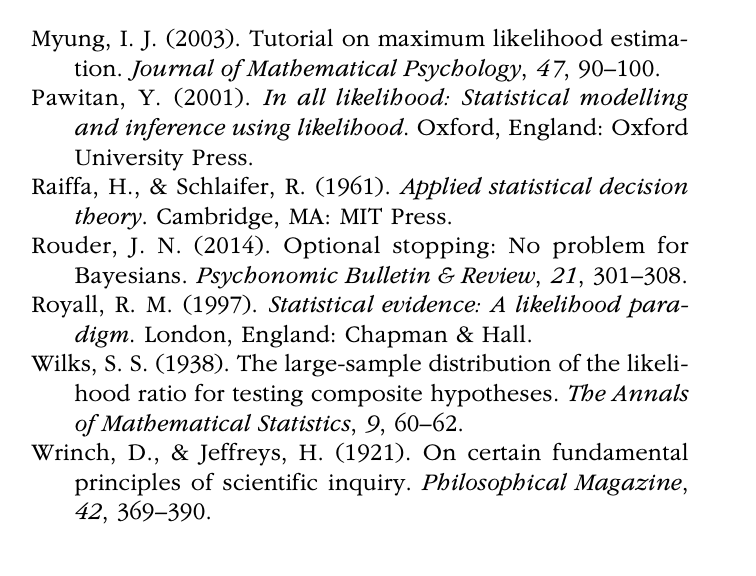

## Annotated references:

Etz, Alexander. 2018. “Introduction to the Concept of Likelihood and Its Applications.” *Advances in Methods and Practices in Psychological Science* 1 (1): 60–69.

Rush, Alexander M. 2018. “The Annotated Transformer.” In *Proceedings of Workshop for Nlp Open Source Software (Nlp-Oss)*, 52–60.